# Introducción a Bioconductor

Octubre 24, 2016

- ¿Quién ha escuchado que es R?
- ¿Quién sabe que es un paquete de R?
- ¿Quién sabe que es Bioconductor?

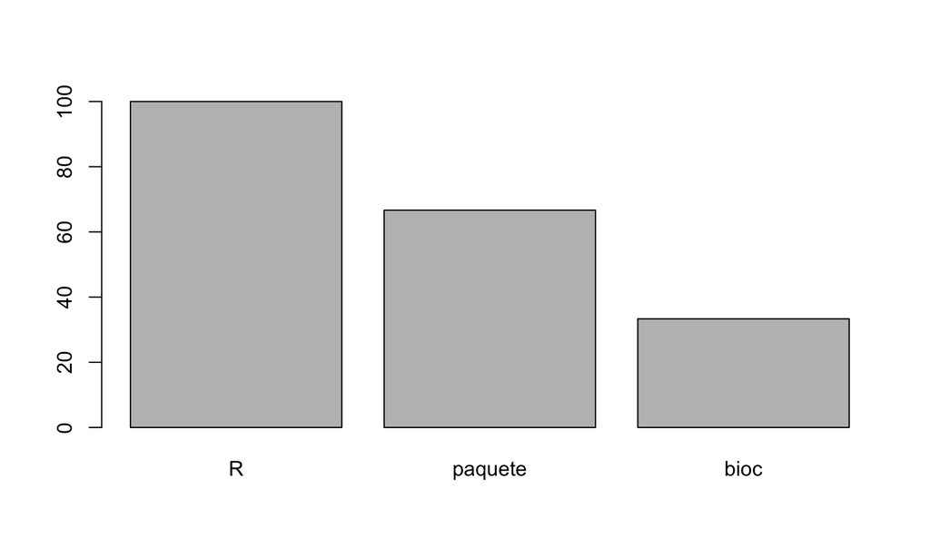

```r
x <- c('R' = 30, 'paquete' = 20, 'bioc' = 10)
x <- x / max(x) * 100
barplot(x)
```

## Paquete de R

- Es la forma en que uno puede expander lo que podemos hacer con R
- Agrupa código, documentación de como usar las funciones y ejemplos demostrando lo que uno puede hacer.
- Los mejores paquetes explican como las funciones se relacionan en un documento *vignette* y tienen pruebas para verificar que el código está funcionando correctamente.
- ¿Qué paquetes de R acabamos de usar?

```r
?max
?barplot
```

- Exploremos un paquete

```r
help(package = 'stats')
```

## ¿Qué es Bioconductor?

- Es un repositorio de paquetes de R enfocados en resolver problemas biológicos
- También es una organización que revisa los paquetes para que sean de alta calidad y funcionen adecuadamente
- Ayudan a usuarios nuevos y ofrecen cursos
- En un escenario ideal, los usuarios terminan siendo desarrolladores de sus propios paquetes
- http://bioconductor.org/

[figure not shown]

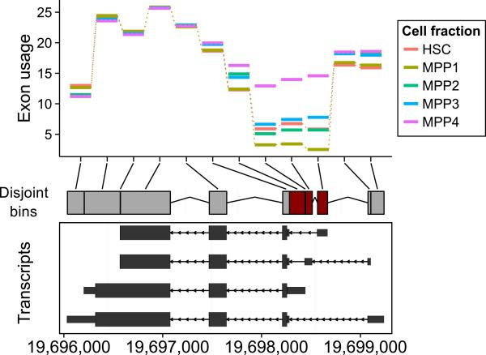

## ¿Cómo encuentro paquetes?

- Google, PubMed, …
- BiocViews: paquetes organizados por las tareas que realizan.
- Hay paquetes de código (software), de datos (experiment) y de anotación
- Ejercicio: ¿qué paquetes nos servirían para expresión diferencial de exones?

¡No hagan trampa!

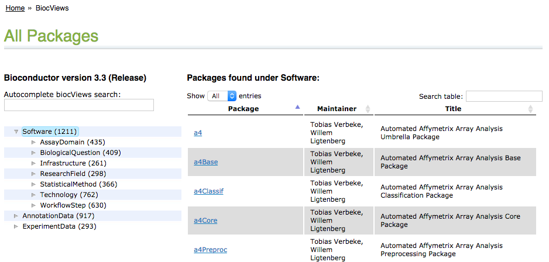

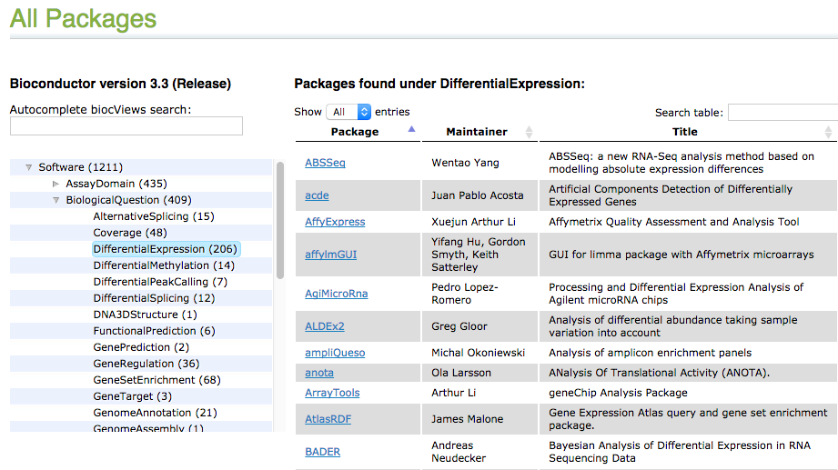

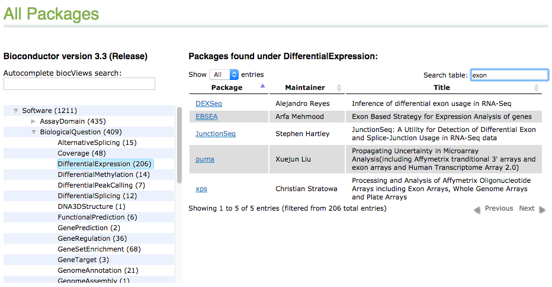

## Encontrando paquetes vía *workflows*

- Un *workflow* es un documento que explica como realizar cierto tipo de análisis
- Útil cuando no conocemos las palabras clave
- Involucran más de un paquete y explican como se relacionan
- Son documentos que no cambian muy seguido
- http://bioconductor.org/help/workflows/

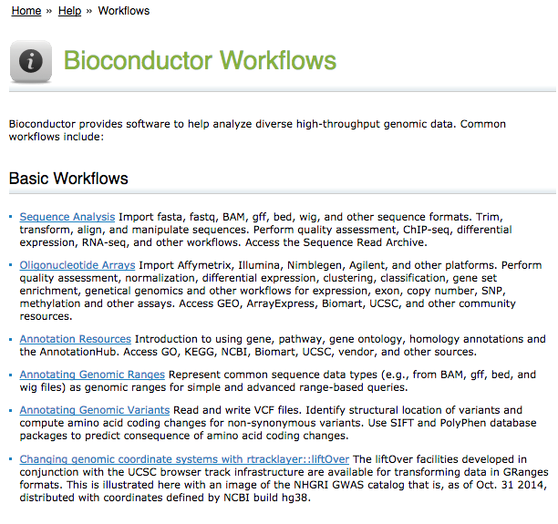

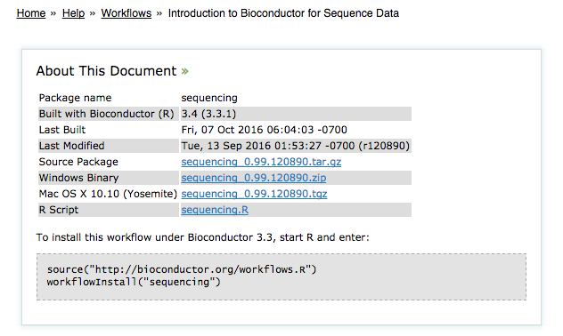

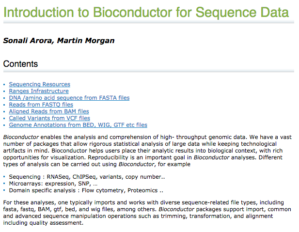

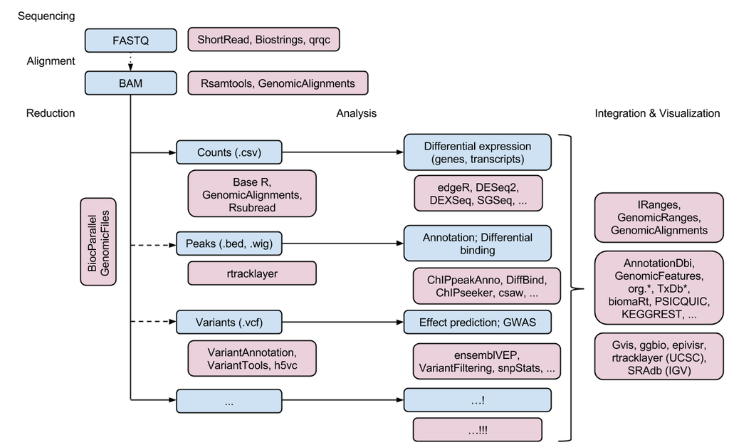

## Encontramos un paquete… ¿qué sigue?

- Explorar la *vignette* para ver que podemos hacer con el paquete
- Generalmente incluye un ejemplo completo con código que podemos correr y obtener los mismos resultados
- Muchos tienen artículos asociados que explican a más detalle los métodos usados en el paquete

[figure not shown]

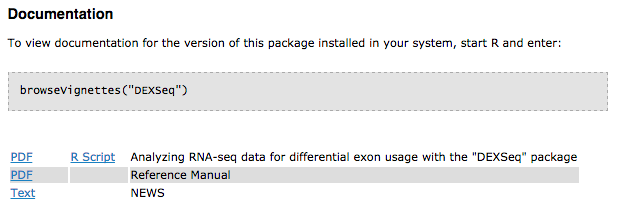

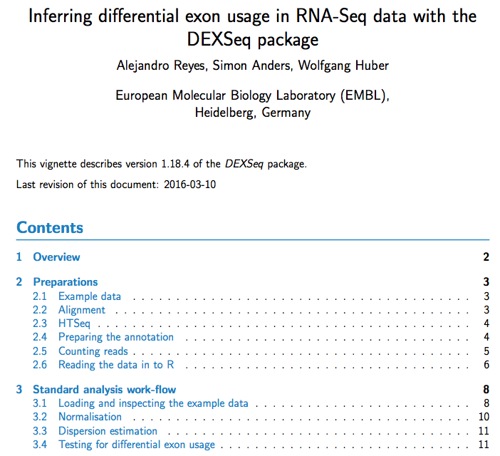

## Detalles técnicos

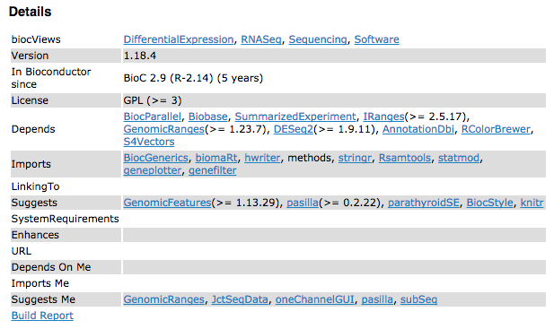

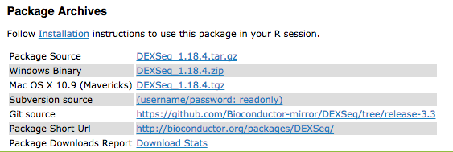

## Un paquete en CRAN

- https://cran.r-project.org/package=pheatmap

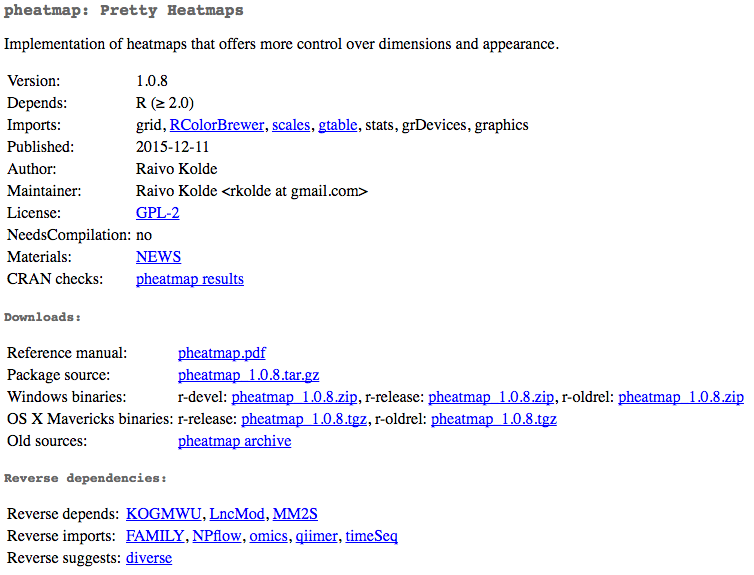

## Instalar paquetes

- CRAN

```r
install.packages('pheatmap')
```

- Bioconductor

```r
## try http:// if https:// URLs are not supported
source("https://bioconductor.org/biocLite.R")
biocLite("DEXSeq")
```

```r
biocLite(c('DESeq2', 'edgeR', 'limma'))
```

- https://www.bioconductor.org/developers/how-to/useDevel/

## Usar un paquete

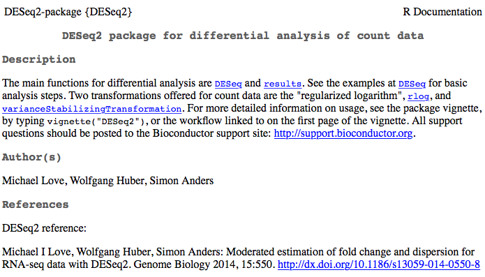

```r
library('DESeq2')
help(package = "DESeq2")
```

## DESeq

```r
?DESeq
```

```r
# see vignette for suggestions on generating
# count tables from RNA-Seq data
cnts <- matrix(rnbinom(n=1000, mu=100, size=1/0.5), ncol=10)
cond <- factor(rep(1:2, each=5))
```

```r
## Exploremos los datos
dim(cnts)
```

```
## [1] 100  10
```

```r
head(cnts[1:2, 1:5])
```

```
##      [,1] [,2] [,3] [,4] [,5]
## [1,]  106   80   23  209   93
## [2,]   75   56   49    4   78
```

```r
cond
```

```
##  [1] 1 1 1 1 1 2 2 2 2 2
## Levels: 1 2
```

## Objeto DESeqDataSet

```r
# object construction
dds <- DESeqDataSetFromMatrix(cnts, DataFrame(cond), ~ cond)
class(dds)
```

```
## [1] "DESeqDataSet"
## attr(,"package")
## [1] "DESeq2"
```

```r
dds
```

```
## class: DESeqDataSet
## dim: 100 10
## metadata(1): version
## assays(1): counts
## rownames: NULL
## rowData names(0):
## colnames: NULL
## colData names(1): cond
```

## Realicemos el análisis

```r
# standard analysis
dds <- DESeq(dds)
dds
```

```
## class: DESeqDataSet
## dim: 100 10
## metadata(1): version
## assays(3): counts mu cooks
## rownames: NULL
## rowData names(27): baseMean baseVar ... deviance maxCooks
## colnames: NULL
## colData names(2): cond sizeFactor
```

```r
res <- results(dds)
res
```

```
## log2 fold change (MAP): cond 2 vs 1
## Wald test p-value: cond 2 vs 1
## DataFrame with 100 rows and 6 columns
##      baseMean log2FoldChange     lfcSE       stat       pvalue        padj
##     <numeric>      <numeric> <numeric>  <numeric>    <numeric>   <numeric>
## 1    80.33843     -0.3981648 0.4002900 -0.9946909    0.3198866   0.7532407
## 2    63.82893      0.4063463 0.4082540  0.9953272    0.3195772   0.7532407
## 3    95.75866     -0.1946514 0.3932954 -0.4949243    0.6206536   0.8848956
## 4    98.13642      0.2169878 0.4075716  0.5323920    0.5944545   0.8848956
## 5    74.20560     -0.4525886 0.4208943 -1.0753021    0.2822395   0.7532407
## ...       ...            ...       ...        ...          ...         ...
## 96   91.48193     -0.1712685 0.4184077 -0.4093341 6.822945e-01 0.922019604
## 97   59.76930      1.5565185 0.3944059  3.9464887 7.930567e-05 0.007930567
## 98   82.91659     -0.7031178 0.3852331 -1.8251751 6.797461e-02 0.601667388
## 99  107.81217     -0.6904754 0.4225979 -1.6338828 1.022835e-01 0.601667388
## 100 115.46462     -0.3740546 0.4215595 -0.8873115 3.749112e-01 0.772219637
```

```r
example('DESeq', package = 'DESeq2')
```

```
##
## DESeq> # see vignette for suggestions on generating
## DESeq> # count tables from RNA-Seq data
## DESeq> cnts <- matrix(rnbinom(n=1000, mu=100, size=1/0.5), ncol=10)
##
## DESeq> cond <- factor(rep(1:2, each=5))
##
## DESeq> # object construction
## DESeq> dds <- DESeqDataSetFromMatrix(cnts, DataFrame(cond), ~ cond)
```

```
##
## DESeq> # standard analysis
## DESeq> dds <- DESeq(dds)
```

```
##
## DESeq> res <- results(dds)
##
## DESeq> # an alternate analysis: likelihood ratio test
## DESeq> ddsLRT <- DESeq(dds, test="LRT", reduced= ~ 1)
```

```
## found already estimated dispersions, replacing these
```

```
##
## DESeq> resLRT <- results(ddsLRT)
```

## Ejercicio

- Tenemos los identificadores de *UNIPROT* de 6 proteínas humanas de interes. ¿Cuál es el símbolo de los genes para las siguientes proteínas?

[output not shown]

## Pasos a realizar

1. Encontrar que paquete tiene la anotación del genoma humano
2. Encontrar la *vignette* que describe como usar ese paquete
3. Obtener los símbolos de los genes

## Solución

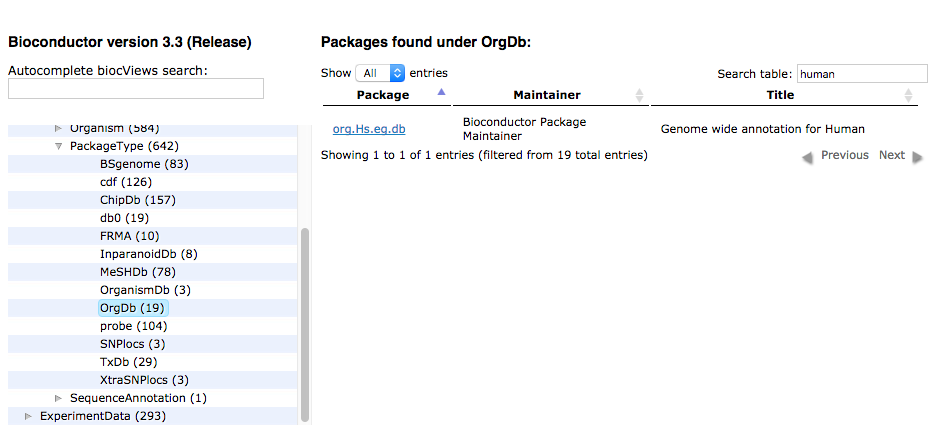

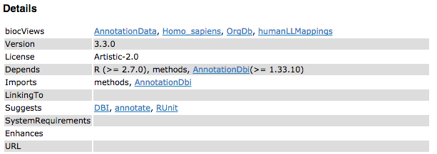

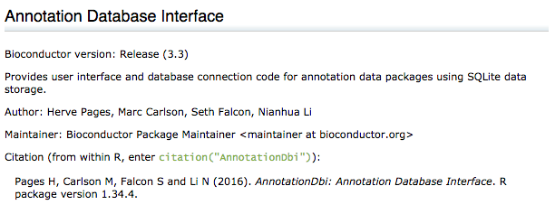

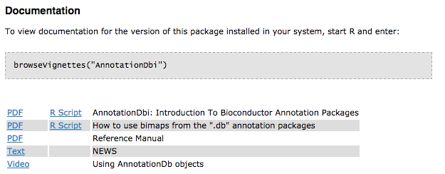

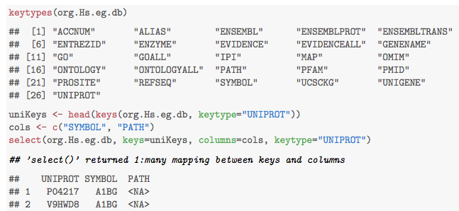

```r
library('org.Hs.eg.db')
uniprot <- c('P61968', 'B2RC63', 'A0A024R9I0',
    'Q13394', 'Q8NGN1', 'P58417')
select(org.Hs.eg.db, keys = uniprot,
    columns = 'SYMBOL', keytype = 'UNIPROT')
```

```
##      UNIPROT   SYMBOL
## 1     P61968     LMO4
## 2     B2RC63     GDF2
## 3 A0A024R9I0 ATP6V1C1
## 4     Q13394  MAB21L1
## 5     Q8NGN1    OR6T1
## 6     P58417    NXPH1
```

## Buscar ayuda

- https://support.bioconductor.org/

[figure not shown]

- https://support.bioconductor.org/local/search/page/?q=deseq2+counts

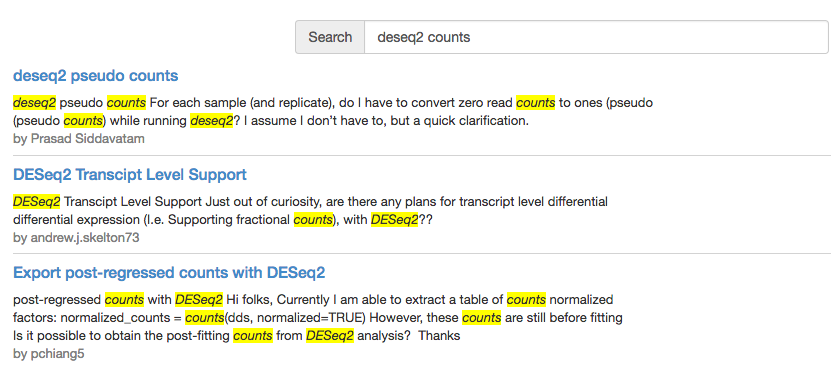

- ¿Qué elementos son importantes para hacer una buena pregunta?
- https://support.bioconductor.org/p/88421/

[figure not shown]

- https://support.bioconductor.org/p/83911/

## Pedir ayuda

- http://www.bioconductor.org/help/support/posting-guide/
- Describir el problema con un ejemplo pequeño que otros puedan reproducir
- Incluir información precisa sobre que paquetes está uno usando y del error
- Etiquetar a los paquetes relacionados para que los autores de ellos sean notificados

## Información de R

```
##  setting  value
##  version  R version 3.3.0 (2016-05-03)
##  system   x86_64, darwin13.4.0
##  ui       X11
##  language (EN)
##  collate  en_US.UTF-8
##  tz       America/Mexico_City
##  date     2016-10-21
```

```
## Packages ---------------------------------------------------------------------------------------------------------------
```

```
##  package              * version  date       source
##  acepack                1.3-3.3  2014-11-24 CRAN (R 3.3.0)
##  annotate               1.50.0   2016-05-04 Bioconductor
##  AnnotationDbi        * 1.34.3   2016-05-23 Bioconductor
##  Biobase              * 2.32.0   2016-05-04 Bioconductor
##  BiocGenerics         * 0.18.0   2016-05-04 Bioconductor
##  BiocParallel           1.6.2    2016-05-16 Bioconductor
##  chron                  2.3-47   2015-06-24 CRAN (R 3.3.0)
##  cluster                2.0.4    2016-04-18 CRAN (R 3.3.0)
##  colorspace             1.2-6    2015-03-11 CRAN (R 3.3.0)
##  data.table             1.9.6    2015-09-19 CRAN (R 3.3.0)
##  DBI                    0.4-1    2016-05-08 CRAN (R 3.3.0)
##  DESeq2               * 1.12.3   2016-05-26 Bioconductor
##  devtools             * 1.12.0   2016-06-24 CRAN (R 3.3.0)
##  digest                 0.6.9    2016-01-08 CRAN (R 3.3.0)
##  evaluate               0.9      2016-04-29 CRAN (R 3.3.0)
##  foreign                0.8-66   2015-08-19 CRAN (R 3.3.0)
##  formatR                1.4      2016-05-09 CRAN (R 3.3.0)
##  Formula                1.2-1    2015-04-07 CRAN (R 3.3.0)
##  genefilter             1.54.2   2016-05-16 Bioconductor
##  geneplotter            1.50.0   2016-05-04 Bioconductor
##  GenomeInfoDb         * 1.8.1    2016-05-12 Bioconductor
##  GenomicRanges        * 1.24.2   2016-06-15 Bioconductor
##  ggplot2                2.1.0    2016-03-01 CRAN (R 3.3.0)
##  gridExtra              2.2.1    2016-02-29 CRAN (R 3.3.0)
##  gtable                 0.2.0    2016-02-26 CRAN (R 3.3.0)
##  highr                  0.6      2016-05-09 CRAN (R 3.3.0)
##  Hmisc                  3.17-4   2016-05-02 CRAN (R 3.3.0)
##  htmltools              0.3.5    2016-03-21 CRAN (R 3.3.0)
##  IRanges              * 2.6.1    2016-06-19 Bioconductor
##  knitr                * 1.13     2016-05-09 CRAN (R 3.3.0)
##  lattice                0.20-33  2015-07-14 CRAN (R 3.3.0)
##  latticeExtra           0.6-28   2016-02-09 CRAN (R 3.3.0)
##  locfit                 1.5-9.1  2013-04-20 CRAN (R 3.3.0)
##  magrittr               1.5      2014-11-22 CRAN (R 3.3.0)
##  Matrix                 1.2-6    2016-05-02 CRAN (R 3.3.0)
##  memoise                1.0.0    2016-01-29 CRAN (R 3.3.0)
##  munsell                0.4.3    2016-02-13 CRAN (R 3.3.0)
##  nnet                   7.3-12   2016-02-02 CRAN (R 3.3.0)
##  org.Hs.eg.db         * 3.3.0    2016-06-27 Bioconductor
##  plyr                   1.8.4    2016-06-08 CRAN (R 3.3.0)
##  RColorBrewer           1.1-2    2014-12-07 CRAN (R 3.3.0)
##  Rcpp                   0.12.5   2016-05-14 CRAN (R 3.3.0)
##  rmarkdown              0.9.6.14 2016-06-27 Github (rstudio/rmarkdown@cb74ee5)
##  rpart                  4.1-10   2015-06-29 CRAN (R 3.3.0)
##  RSQLite                1.0.0    2014-10-25 CRAN (R 3.3.0)
##  S4Vectors            * 0.10.1   2016-05-23 Bioconductor
##  scales                 0.4.0    2016-02-26 CRAN (R 3.3.0)
##  stringi                1.1.1    2016-05-27 CRAN (R 3.3.0)
##  stringr                1.0.0    2015-04-30 CRAN (R 3.3.0)
##  SummarizedExperiment * 1.2.3    2016-06-10 Bioconductor
##  survival               2.39-5   2016-06-26 CRAN (R 3.3.0)
##  withr                  1.0.2    2016-06-20 CRAN (R 3.3.0)
##  XML                    3.98-1.4 2016-03-01 CRAN (R 3.3.0)
##  xtable                 1.8-2    2016-02-05 CRAN (R 3.3.0)
##  XVector                0.12.0   2016-05-04 Bioconductor
##  yaml                   2.1.13   2014-06-12 CRAN (R 3.3.0)
##  zlibbioc               1.18.0   2016-05-04 Bioconductor
```

## traceback()

```r
library('IRanges')
IRanges('a')
traceback()
```

## Estar al día

- *NEWS*
- Via twitter: https://twitter.com/bioconductor
- Con las *newsletter* desde la página principal http://bioconductor.org/help/newsletters/2016_January/
- Llendo a cursos http://bioconductor.org/help/events/

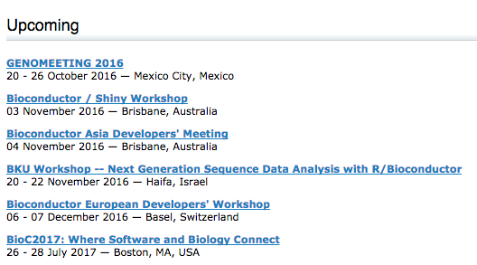

- http://bioconductor.org/help/course-materials/

## Más información

- http://lcolladotor.github.io/2014/10/16/startBioC#.WAYwcZMrKso
- http://bioconductor.org/about/
- http://bioconductor.org/help/course-materials/2016/CSAMA/lab-1-intro-to-r-bioc/html/L1.2-bioc-intro-morgan.html
- Huber et al., 2015 Nature Methods 12:115-121 https://www.ncbi.nlm.nih.gov/pubmed/25633503